# Inleiding

Het onderzoek vond plaats in de maanden mei en juni van het jaar 2023, aan de Hanzehogeschool te Groningen. Er is ook gemeten in Groningen centrum en Zwolle centrum.

# Introductie

## Doel

Het doel van het onderzoek is bekijken of er bij studenten van de Hanzehogeschool Groningen aanleg is voor een bepaalde oogkleur. Daarnaast is er op 2 andere locaties gemeten om verschillen te kunnen onderzoeken in oogkleur en zo te bepalen of er aanleg is voor een bepaalde oogkleur bij studenten van de hogeschool.

## Data collectie

De data is verzameld op 3 verschillende locaties, waarbij op elke locatie 40 verschillende proefpersonen zijn bevraagd. De locaties zijn respectievelijk Hanzehogeschool (Van DoorenVeste), Groningen centrum en Zwolle centrum. De proefpersonen zijn in daglicht bevraagd en indien de locatie binnen was bij voorkeur bij goed licht (bij een raam of bij goede TL verlichting). Hier is de oogkleur van de proefpersonen bekeken.

Op de Hanzehogeschool Groningen is de informatie binnen verzameld. In Groningen centrum en Zwolle centrum buiten.

## Theorie

### Oorzaak

De oogkleur wordt bepaald door de hoeveelheid en kwaliteit van het pigment melanine in de iris. Melanine wordt geproduceerd door cellen genaamd melanocyten (pigmentcellen). Melanocyten bevinden zich in verschillende delen van het lichaam zoals de huid, het haar en dus ook de ogen. in het oog zitten melanocyten in het bindweefsel. Dit bindweefsel wordt stroma genoemd. De hoeveelheid melanocyten is ongeacht de oogkleur gelijk bij iedereen. Er is dus geen verband tussen de hoeveelheid melanocyten en de oogkleur, maar wel tussen de hoeveelheid en kwaliteit van melanine in de iris. Dit zorgt voor de vele variaties in oogkleuren.

### Verschillen in oogkleur

Mensen met een bruine iris hebben over het algemeen meer melanine in hun ogen t.o.v. mensen met een blauwe/groene iris. Dit komt doordat mensen met een bruine iris in de voorste laag en het stroma van de iris meer melanocyten en melanosomen hebben dan mensen met een blauwe/groene iris. Melanosomen zijn celorganellen die zich in de melanocyten bevinden. Hierin wordt het pigment opgeslagen. Zowel melanocyten als melanosomen zijn verantwoordelijk voor de productie van melanine. Wanneer licht door een grote hoeveelheid melanine gaat, wordt het meeste zichtbare licht geabsorbeerd en een klein deel teruggekaatst, dit zorgt voor de bruine kleur van de iris. Bij weinig aanwezigheid van melanine is de oogkleur lichter, zoals blauw of groen. Als er te weinig melanine is om een sterke kleur blauw te produceren worden de kleuren van bloedvaten (rood) en de kleine hoeveelheid blauwe pigment weerkaatst wat voor een violet kleur zorgt. Er zijn ook gevallen waarbij er helemaal geen melanine aanwezig is, dit wordt ook wel albinisme genoemd. Bij gebrek aan melanine ontstaan er rode ogen. Een rode iris is zoals eerder uitgelegd een weerkaatsing van de bloedvaten in het oog.

### Expressie en dominantie

Ogen zijn er in verschillende soorten blauw, bruin en groen. Het allel dat verantwoordelijk is voor de kleur bruin is dominant over het allel voor blauw en het allel voor groen. Hierbij is het allel voor groen weer dominant over blauw. Een verminderde expressie kan voor een onvolledige dominantie zorgen. Dit veroorzaakt de vele verschillende kleuren van de iris zoals hazelnoot en lichtere tinten bruin.

### Heterochromie

Het kan ook voorkomen dat de iris zelf uit verschillende kleuren bestaat. Dit wordt heterochromie genoemd. Deze aandoening wordt geërfd of veroorzaakt door somatische mutaties in de cellen (bij somatische mutaties vinden er mutaties plaats in cellen die niet betrokken zijn bij geslachtscellen). Het is ook mogelijk dat de aandoening wordt veroorzaakt door (gedeeltelijke) inactivatie van bepaalde genen in de cellen. Hierdoor wordt er op sommige plaatsen in het iris minder pigment geproduceerd dan op andere plaatsen en ontstaat er een iris met meer dan 1 kleur.

# Experimentele verzetting

Er is van 3x 40 proefpersonen de oogkleur, het geslacht en de leeftijd verzameld. De oogkleur is van zowel het linker- als rechteroog genoteerd en verwerkt in een spreadsheet. Deze spreadsheet is omgezet in een .csv bestand zodat deze ingelezen kan worden in R markdown.

# Logboek

## 09-05-2023 nd-nd - 458075(Willem Daniël Visser)

Een refferentie afbeelding is gemaakt als refferentie voor de metingen. Er is een afbeelding opgezocht met foto’s van mensen hun ogen in vele verschillende kleuren. Deze afbeelding (zie github) is bewerkt door het toevoegen van 2 strepen bruin, 2 blauw en 1 groen. Dit voor snelle herkenning van kleur categorie zodra de oogkleur van de subject overeenstemd met de foto op de afbeelding. Voor meer informatie zie het protocol.

## 11-05-2023 09:00 - 10:00 - ALL

Gedurende 1 uur zijn op de Hanzehogeschool Groningen (Van DoorenVeste) 40 verschillende studenten bevraagd naar leeftijd en geslacht. Daarna is door 4 verschillende analisten van al deze proefpersonen zowel de rechter- als linkeroogkleur genoteerd bij de identifier van de proefpersoon. Hierbij is gezorgd voor een goede verdeling tussen mannen en vrouwen.

## 11-05-2023 10:45 - 12:00 - ALL

Gedurende 1 uur zijn in Grongingen centrum 40 verschillende proefpersonen bevraagd naar leeftijd en geslacht. Daarna is door 4 verschillende analisten van al deze proefpersonen zowel de rechter- als linkeroogkleur genoteerd bij de identifier van de proefpersoon. Hierbij is gezocht naar proefpersonen die een verwachtte leeftijd hadden van 16 - 30 jaar (studentenleeftijd) en is gezorgd voor een goede verdeling tussen mannen en vrouwen.

## 15-05-2023 13:30 - 15:30 - ALL

Gedurende 2 uur zijn in Zwolle centrum 40 verschillende proefpersonen bevraagd naar leeftijd en geslacht. Daarna is door 4 verschillende analisten van al deze proefpersonen zowel de rechter- als linkeroogkleur genoteerd bij de identifier van de proefpersoon. Hierbij is gezocht naar proefpersonen die een verwachtte leeftijd hadden van 16 - 30 jaar (studentenleeftijd) en is gezorgd voor een goede verdeling tussen mannen en vrouwen.

## 16-05-2023 nd-nd - 458075(Willem Daniël Visser)

De refferentie afbeelding is op github gezet.(Zie commit: 4f00cc1f618da9ca344627c1cf6c2b473f0ad09e)

## 22-05-2023 nd-nd - 458075(Willem Daniël Visser)

De bestandenstructuur is aangepast en de .gitignore is daarbij toegevoegd. (Zie commits: a5b1e3c96ee792df2c83e87ec83e5160e62333fc, 764e3a8c90602eb1a52046c9a0816540263592b0)

## 30-05-2023 nd-nd - 458075(Willem Daniël Visser)

Aan het .gitignore bestand is de map ruwe_data/ toegevoegd, zo kunnen analisten wel de data lokaal houden, maar hoeft het niet op github gepubliceerd te worden. (Zie commit: 1081ca6a847ec6254a45887f2d74d8b2e2fde975)

## 30-05-2023 10:30 - 11:50 - 458075(Willem Daniël Visser)

Gedurende 1,5 uur heeft onderzoeker 458075 de oogkleur data ingeladen met behulp van de `read.table` functie in dyplyr. Toen is de data verwerkt door het transformeren van de kolommen: “geslacht”, “LR”(links en rechts kant van het gemeten oog) en “analist”. Daarna zijn een aantal oogkleur namen getest op aanwezigheid in de dataframe kolom “oogkleur”. Hieruit is een positief resultaat gekomen. Tenslotte is ook de kolom “oogkleur” omgezet in een factor.

```r
library(plyr)
library(dplyr)
library(ggplot2)
library(knitr)
```

```r
file_path = "../analyse/data/Oogkleur_simpel2.csv"
eye_df <- read.table(
  file = file_path,
  header = T,
  sep = ",",
  na.strings = c("-")
)
kable(eye_df[1:10,])
```

| Identifier | geslacht | leeftijd | LR | analist | oogkleur |
| --- | --- | --- | --- | --- | --- |
| A001 | M | 20 | L | 9308 | blauw |
| A001 | M | 20 | R | 9308 | blauw |
| A001 | M | 20 | L | 2193 | blauw |
| A001 | M | 20 | R | 2193 | blauw |
| A001 | M | 20 | L | 5609 | blauw |
| A001 | M | 20 | R | 5609 | blauw |
| A001 | M | 20 | L | 8705 | blauw |
| A001 | M | 20 | R | 8705 | blauw |
| A002 | F | 19 | L | 9308 | hazel |
| A002 | F | 19 | R | 9308 | hazel |

```r
eye_df$geslacht = factor(
  eye_df$geslacht,
  levels = c("M", "F"),
  labels = c("F", "M")
)
eye_df$LR = factor(
  eye_df$LR,
  levels = c("L", "R"),
  labels = c("L", "R")
)
eye_df$analist = factor(
  eye_df$analist,
  levels = c("9308", "2193", "5609", "8705"),
  labels = c("9308", "2193", "5609", "8705")
)
```

```r
# Moet 1 keer FALSE terug geven en 4 keer TRUE
oogkleur_names <- list("grijs", "groen", "blauw", "bruin", "hazel")

for (oogkleur_name in oogkleur_names) {
  print(eye_df %>%
  filter(
    oogkleur == oogkleur_name
  ) %>%
  nrow() > 0)
}
```

```
## [1] FALSE
## [1] TRUE
## [1] TRUE
## [1] TRUE
## [1] TRUE
```

```r
eye_df$oogkleur <- factor(
  eye_df$oogkleur,
  levels = c("blauw", "groen", "bruin", "hazel"),
  labels = c("blauw", "groen", "bruin", "hazel")
)
sapply(eye_df, class)
```

```
##  Identifier    geslacht    leeftijd          LR     analist    oogkleur
## "character"    "factor"   "integer"    "factor"    "factor"    "factor"
```

## 30 & 31-05-2023 13:30-18:00 & 11:45-12:10 & 12:40-14:00 & 17:00-20:00 - 458075(Willem Daniël Visser)

De hypothese is dat er een significant verschil zit tussen de verschillende analisten. Om dit te bewijzen is de chi-square test gedaan over alle analisten en hun gemeten oogkleuren voor zowel links als rechts. Met de code hieronder zijn alle opnames met een NA-waarde verzameld, toen zijn deze gefilterd uit de `eye_df` gehaald samen met de andere opnames die hetzelfde `$Identifier` hebben. Daarna zijn de analist en oogkleur kolommen erin behouden. Vervolgens is de `chisq` functie gebruikt voor de chi square meetfout analyse over alle analisten samen.

```r
# filter uit alle opnames van een Identifier, waar 1 of meerdere NA waarden bij voorkomen
# dit is om het aantal opnames per analist in totaal gelijk te houden
eye_df_na_cases <- eye_df[!complete.cases(eye_df), ]


eye_df_analist_eyecolor <- eye_df[
  !(eye_df$Identifier %in% eye_df_na_cases$Identifier),
]
eye_df_analist_eyecolor <- eye_df_analist_eyecolor %>%
  select(analist, oogkleur)

kable(eye_df_analist_eyecolor[1:5,])
```

| analist | oogkleur |
| --- | --- |
| 9308 | blauw |
| 9308 | blauw |
| 2193 | blauw |
| 2193 | blauw |
| 5609 | blauw |

```r
eye_df_analist_eyecolor_chisq <- chisq.test(
  eye_df_analist_eyecolor$analist,
  eye_df_analist_eyecolor$oogkleur
)

# observed eye colors per analist
kable(eye_df_analist_eyecolor_chisq$observed)
```

|  | blauw | groen | bruin | hazel |
| --- | --- | --- | --- | --- |
| 9308 | 132 | 20 | 60 | 18 |
| 2193 | 125 | 22 | 64 | 19 |
| 5609 | 114 | 38 | 58 | 20 |
| 8705 | 110 | 36 | 72 | 12 |

```r
# expected eye colors per analist
kable(eye_df_analist_eyecolor_chisq$expected)
```

|  | blauw | groen | bruin | hazel |
| --- | --- | --- | --- | --- |
| 9308 | 120.25 | 29 | 63.5 | 17.25 |
| 2193 | 120.25 | 29 | 63.5 | 17.25 |
| 5609 | 120.25 | 29 | 63.5 | 17.25 |
| 8705 | 120.25 | 29 | 63.5 | 17.25 |

```r
paste("p-waarde chi-square = ", round(eye_df_analist_eyecolor_chisq$p.value, 5))
```

```
## [1] "p-waarde chi-square =  0.07672"
```

De 0-hypothese moet worden geaccepteerd (α = .05). Er is dus geen significant verschil tussen de analisten.

## 01-06-2023 9:00-11:10 - 458075(Willem Daniël Visser)

Als gevolg van de zichtbare verschillen tussen analist 9308 en 8705 in de kwantitatieve tabel, is er een chi-square test gedaan op deze twee.

```r
analist_lst <- list(9308, 2193, 5609, 8705)

eye_df_analist_eyecolor_2 <- eye_df_analist_eyecolor %>%
  filter((analist == 9308) | (analist == 8705))


paste("p-waarde chi-square = ", round(
  chisq.test(
    eye_df_analist_eyecolor_2$analist,
    eye_df_analist_eyecolor_2$oogkleur
  )$p.value, 5
))
```

```
## [1] "p-waarde chi-square =  0.03118"
```

Het verschil is significant en dus verschillen deze twee analisten sterk van elkaar.

## 01-06-2023 11:10-11:35 - 458075(Willem Daniël Visser)

De volgende hypotheses waarom de meetfout tussen analist 9308 en 8705 zo groot waren zijn opgesteld:

- De focus op detail bij de analisten zorgt voor het meenemen of weglaten van details in het oog (zoals vlekjes of een overgang naar andere kleuren)
- De oogkleuren zijn vaak vergelijkbaar met andere oogkleuren, dus heeft de ene analist door willekeurigheid of andere kennis en ervaringen die tot de keuze van de ene kleur of de ander leid
- De ene analist heeft meer op het vergelijkings blaadje gekeken dan de ander

De volgende hypotheses waarom er een meetfout zit tussen de verschillende analisten:

- Mensen zijn inaccuraat bij het bepalen van kleuren
- De analisten stonden niet altijd op de zelfde afstand.
- De analisten keken niet even lang naar de proefpersoon

## 01&02&03-06-2023 nd.-nd. - 458075(Willem Daniël Visser)

Deze dagen word literatuur bewijs voor de hypotheses verzameld. Er staan korte samenvattende zinnen waar ze het over hebben, om later met deze feiten conclusies te trekken:

Hoe iemand kleur waarneemt hangt af van vele factoren. [1] heeft het over de 2 fenomenen kleur contrast en kleur constantheid in de intro. [2] heeft het over de sexe verschil in het waarnemen van kleuren en hoe vrouwen meer gevoel hebben voor kleur dan mannen. [3] heeft het over verschillende kleurblindheden en het feit dat dit minder vaak voorkomt bij vrouwen. Ook heeft het over verschillende niveaus van kleurenblindheid. [4] Zegt dat mensen verschillende meningen hebben over kleur, genoeg om onderzoek met voorgedefinieerde kleuren te vermeiden. Ze claimt dat het licht aan fysiologische, taal en cultuur verschillen.

[1] R. Beau Lotto, & Purves, D. (2002). *The empirical basis of color perception*. *11*(4), 609–629. https://doi.org/10.1016/s1053-8100(02)00014-4

[2] Bimler, D. L., Kirkland, J., & Jameson, K. A. (2004). Quantifying variations in personal color spaces: Are there sex differences in color vision? *Color Research & Application*, *29*(2), 128–134. https://doi.org/10.1002/col.10232

‌[3] Neitz, M., & Neitz, J. (2000). *Molecular Genetics of Color Vision and Color Vision Defects*. *118*(5), 691–691. https://doi.org/10.1001/archopht.118.5.691

[4] Valenta, K., Bornbusch, S. L., Jacques, Y.-D., & Nevo, O. (2021). *In the eye of the beholder: Is color classification consistent among human observers?* *11*(20), 13875–13883. https://doi.org/10.1002/ece3.8093

## 04-06-2023 11:45-12:40 & 14:40-16:10 - 458075(Willem Daniël Visser)

Opnieuw word er literatuur bewijs voor de hypotheses verzameld.

[5] heeft geen significant verschil tussen factoren(sexe, leeftijd, ect) gevonden in haar experiment.

[5] Impact of Color-Matching Primaries on Observer Matching: Part I – Accuracy. (2022). Retrieved June 4, 2023, from LEUKOS website: https://www.tandfonline.com/doi/full/10.1080/15502724.2020.1864395

## 05-06-2023 09:35-09:45 - 458075(Willem Daniël Visser)

Er is een opgestapelde barplot gemaakt met alle oogkleuren per analist tegen het aantal tellingen van deze oogkleuren.

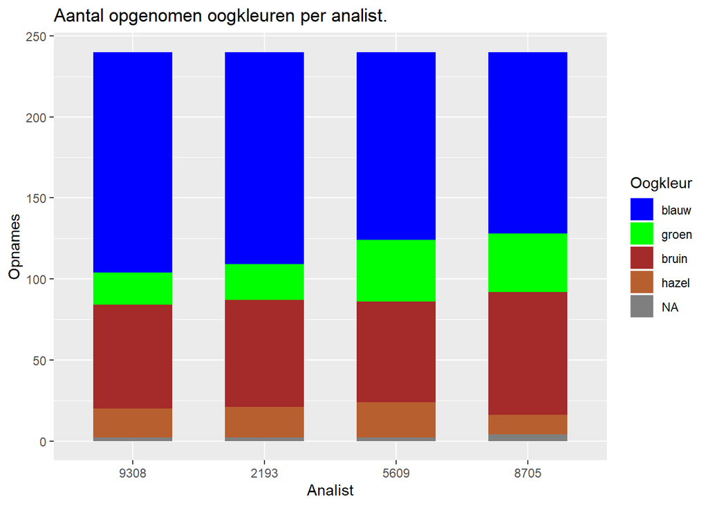

```r
ggplot(eye_df, aes(x = analist, fill = oogkleur)) +
  geom_bar(width = .6) +
  scale_fill_manual("Oogkleur", values = c("blue", "green", "brown", "#B85F2F")) +
  ylab("Opnames") +
  xlab("Analist") +
  ggtitle("Aantal opgenomen oogkleuren per analist.")
```

### 12:30-13:30

Er is nog meer literatuur bewijs verzameld. [7] is een tegen argument voor het gebruik van foto’s als oogkleur detectie.

[6] verteld dat mensen niet alleen op basis van gegeven aspecten een beslissing maken, maar ook op basis van metacognitive ervaringen. [7] heeft onafhankelijk onderzoek gedaan naar iris herkenning en zegt dat iris patronen gebruiken voor persoons-herkenning betrouwbaar is.

[6] Schwarz, N. (2004). *Metacognitive Experiences in Consumer Judgment and Decision Making*. *14*(4), 332–348. https://doi.org/10.1207/s15327663jcp1404_2

[7] Masek, L. (2003). *Recognition of Human Iris Patterns for Biometric Identification*. Retrieved from http://azadproject.ir/wp-content/uploads/2014/07/Recognition-of-Human-Iris-Patterns-for-Biometric-Identification.pdf

### 13:30-14:10

De discussie en conclusie is geschreven over de deelvraag: “Is er een significant verschil tussen de analisten”.

#### Discussie

Uit de Pearson’s Chi-squared test blijkt er geen significant verschil te zijn tussen de analisten(p = 0.07672). Uitgaande van α = .05. Een korte kijk naar de tabel met aantal detecties van de oogkleuren onder de analisten geeft een groot verschil aan tussen analist 9308 en 8705. Bij een chi-square tussen deze twee blijkt er wel een significant verschil te zijn (p = 0.03118, α = .05).

#### Conclusie

Er is over het algemeen een overeenkomst tussen de analisten, maar ook een duidelijk ruimte voor vermindering van de meetfout. Factoren als sexe, phsygologie en beoordeling van de verhoudingen tussen kleuren(welke kleur is meer aanwezig).

### 15:30-15:45

Na overleg worden de volgende onderwerpen opgeschreven die nog over de data moet worden beschreven:

- Wat is het verschil in %
  - Hoeveel % kans op een verschil van mening
  - Hoeveel % kans op een tie
- Wat waren de karateristics van de …
  - Omstandigheden
  - Analisten
  - Subjects
- Wat welke variabelen gecontroleerd hadden kunnen worden

Deze onderwerpen vervangen de losse hypotheses van 1 juni in dit logboek.